# Weekly Exports of Corn, Soybeans, and Wheat during the 2018 Trade War with China

All eyes are on export sales and shipments of soybeans in the midst of the 2018 trade war.

I always have my commodity price analysis students produce those ‘export pace of use’ charts as a lab assinment because it is data that is very actively followed in the commodity marketing business and because I get to teach them how to use pivot tables in Excel. I’ve had a hankering for awhile to produce the same graphs with `tidyverse` functions in R, and this year I am especially interested in following the progress of export sales and shipments to see how the trade war is playing out.

First, I’ll jus present graphs, and below I will provide the code to reproduce the charts on your own if you want. I’ll be updating them frequently for the next few weeks for my own interest.

I’m going to use the export inspection data from the USDA Federal Grain Inspection Services (FGIS) rather than the more commonl followed Foreign Aricultural Service (FAS) export sales data. Mostly this is because its what I use in my class the FGIS provides every export inspection as a datapoint in a .csv file and gives us the opportunity to do a little more intense data work.

Since ‘sales’ and ‘export inspections’ at the port do not happen at the same time, the graphs in this post look different than what you typcially see tweeted after the FAS report comes out on Thursdays. The FAS report gives us information faster because we know about sales within one week (or one day for the big sales). However, sometimes these sales are cancelled before they get shipped, so the FGIS data is exports that we know left the ports.

First the weekly export inspections for soybeans in 2018 compared to 2013-2017.

The last couple of weeks’ export inspections have been the worst since 2013.

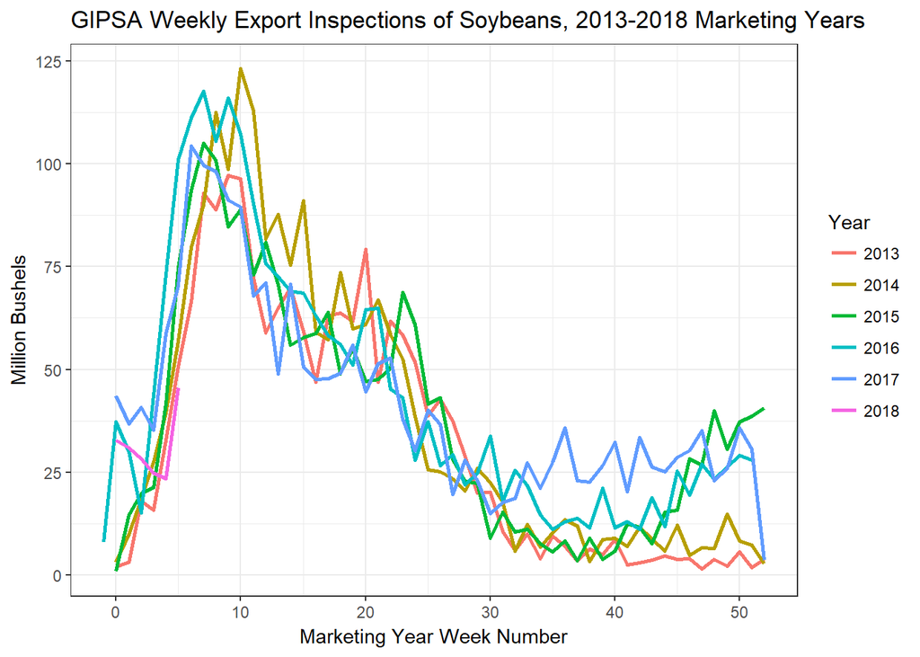

Looking at the cumulative inspections for the 2018 marketing year, export shipments of soybeans are off to the worst start since 2015.

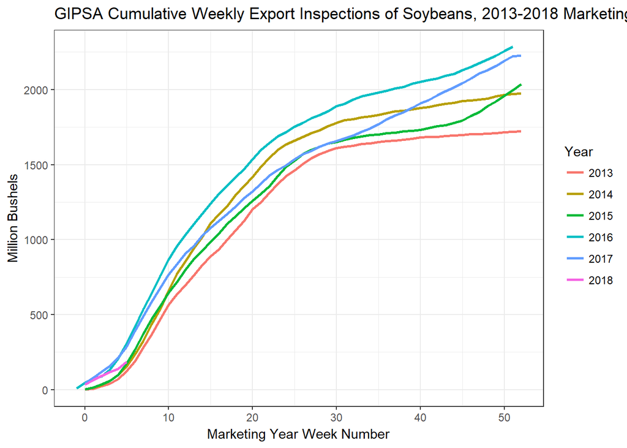

As I said, this data is behind what we know from the FAS export sales report and this weeks sales were ‘disappointing’. INTL FCStone had this assessment:

> Export sales report was a disaster for soybeans, with 2018/19 sales of just 16.2 million bushels, down from 55.9 mbu last week, 64.2 mbu last year, and the lowest week-five total in at least a decade. https://t.co/y5ghb0LpaB [pic.twitter.com/pFlDZlO7We](https://t.co/pFlDZlO7We)

> — INTL FCStone (@INTLFCStone) [October 15, 2018](https://twitter.com/INTLFCStone/status/1051835549131116546?ref_src=twsrc%5Etfw)

Of course, China is the reason for this. If we plot the week 1-6 export inspections for China since 2013, this year’s are the tiny pink bars in week’s 1 and 6. There were no export inspections in weeks 2-5.

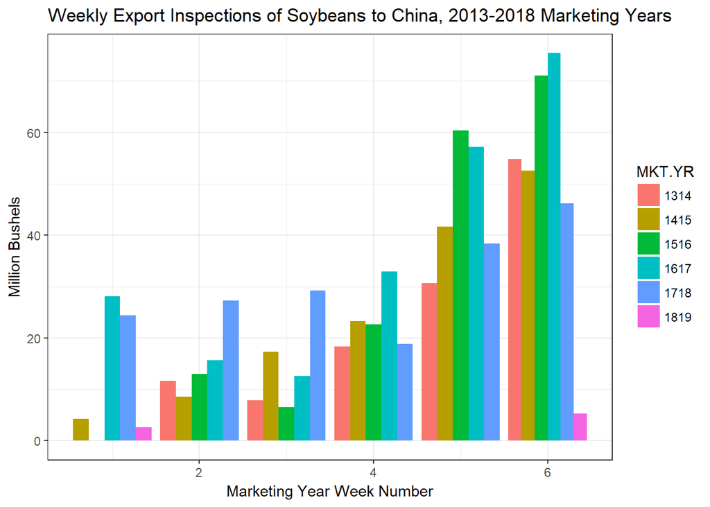

For context here is the cumulative weekly export inspections for corn.

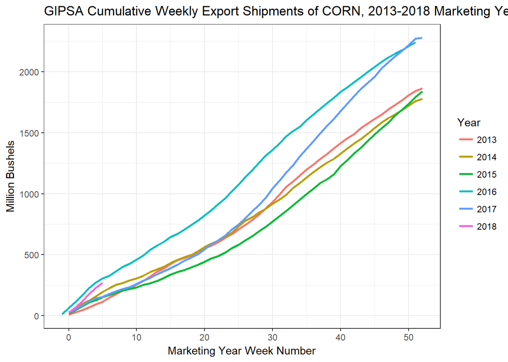

And for wheat (all varieties).

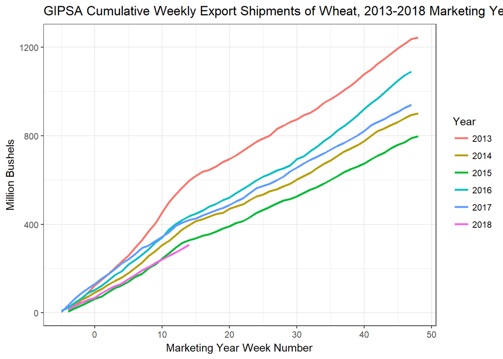

The code to reproduce (and therefore update!) all of the charts yourself is below.

```
library(tidyverse)

# Get the data from GIPSA
DATA_2018 <- read.csv(file = "https://fgisonline.ams.usda.gov/ExportGrainReport/CY2018.csv")
DATA_2017 <- read.csv(file = "https://fgisonline.ams.usda.gov/ExportGrainReport/CY2017.csv")
DATA_2016 <- read.csv(file = "https://fgisonline.ams.usda.gov/ExportGrainReport/CY2016.csv")
DATA_2015 <- read.csv(file = "https://fgisonline.ams.usda.gov/ExportGrainReport/CY2015.csv")
DATA_2014 <- read.csv(file = "https://fgisonline.ams.usda.gov/ExportGrainReport/CY2014.csv")
DATA_2013 <- read.csv(file = "https://fgisonline.ams.usda.gov/ExportGrainReport/CY2013.csv")

DATA      <- rbind(DATA_2013, DATA_2014, DATA_2015, DATA_2016, DATA_2017, DATA_2018)
DATA      <- DATA %>% select(Thursday, Grain, Pounds, Destination, MKT.YR) %>%
                   separate(col = 'Thursday', sep = c(4, 6), into = c('Year', 'Month', 'Day'), remove = TRUE, convert = FALSE) %>%
                   unite(col = 'Date', Year, Month, Day, sep = '-', remove = FALSE)

DATA$Date <- as.Date(DATA$Date)
DATA$Pounds <- DATA$Pounds/56/1000000  # Converts lbs to million bu

######################################
# For soybeans

# If a tidyverse person reads this: I have to separate out marketing years because if I keep the data in one big dataframe and some over weeks since 09-01 I will mix crop years because right when harvest begins both new crop and old crop are being exported. In the raw .csv you will see for the same …

# 2013
soy_13 <- filter(DATA, Grain == "SOYBEANS" & MKT.YR == '1314') %>%
  mutate(MkYrWk = floor(difftime(Date, '2013-09-01', units = "weeks"))) %>% # Calculate the week of the marketing year
  group_by(MkYrWk) %>%
  summarize(WkTotal = sum(Pounds)) %>% # Sum total pounds inspected each week of the mkting year
  mutate(WkCumSum = cumsum(WkTotal))   # Calculate a cumulative sum of pounds inspected by week.

soy_13$Year <- '2013'                  # Attach a year identifier for when we paste the years back together

# 2014
soy_14 <- filter(DATA, Grain == "SOYBEANS" & MKT.YR == '1415') %>%
  mutate(MkYrWk = floor(difftime(Date, '2014-09-01', units = "weeks"))) %>%
  group_by(MkYrWk) %>%
  summarize(WkTotal = sum(Pounds)) %>%
  mutate(WkCumSum = cumsum(WkTotal))

soy_14$Year <- '2014'
```

[output cut: 190 more lines]

```
  group_by(MkYrWk) %>%
  summarize(WkTotal = sum(Pounds)) %>%
  mutate(WkCumSum = cumsum(WkTotal))

wheat_18$Year <- '2018'

wheat <- rbind(wheat_13, wheat_14, wheat_15, wheat_16, wheat_17, wheat_18)

wheat$MkYrWk <- as.numeric(wheat$MkYrWk)
wheat$Year  <- as.factor(wheat$Year)

ggplot(wheat, aes(x = MkYrWk, y = WkCumSum, color = Year)) +
  geom_line(size = 1) +
  theme_bw() +
  labs(title = "GIPSA Cumulative Weekly Export Shipments of Wheat, 2013-2018 Marketing Years", x = 'Marketing Year Week Number', y = 'Million Bushels')
```